# Data Wrangling with MongoDB: Austin, Texas

### Kevin Burnham

Table of Contents

1. Introduction
2. Auditing & Cleaning
3. Exporting to MongoDB
4. Querying the Database
5. Conclusion
6. Bibliography
7. Code

## Introduction

In this project we begin with an XML file provided by OpenStreetMaps (OSM). We audit and clean the data of interest to us and then export it to a MongoDB database using an intermediary JSON file. Finally, we query the data to see what we can learn about Austin.

## Auditing & Cleaning

We begin by getting a count of all the different tag types that we find in the data. We then identify the information that is most valuable to us, audit those data to determine what types of wrangling is necessary and write helper functions to do that wrangling.

As a first step we count the tags with this `count_tags` function and get the following result:

```
{'bounds': 1,
 'member': 10712,
 'nd': 880991,
 'node': 761182,
 'osm': 1,
 'relation': 938,
 'tag': 527014,
 'way': 78371}
```

Since we are interested mainly in places to go in Austin, we will take a closer look at that tags in our nodes. With the `count_keys` function we count the number of occurences of each key in the tags of nodes only. The most common keys are:

- ele 1599
- gnis:feature_id 1443
- name 4774
- highway 8013
- power 2059
- amenity 3324
- created_by 5446

Next, we choose several key types to focus on and make a list of the values contained in those keys. The function below takes in a tag key type (e.g. 'amenity') and an XML file and returns a count of the values associated with that key:

```
def count_values(key, filename):
    counter = collections.Counter()
    for item, elem in ET.iterparse(filename):
        if elem.tag == 'node':
            for tag in elem.findall('tag'):
                if tag.attrib['k'] == key:
                    counter[(tag.attrib['v'])] += 1
    return counter
```

Using the `count_values` function and focusing on tags of special interest to us, we identify problems and opportunities in the OSM data, describe our proposed solutions and link to the helper functions we will use when we export data to the JSON file.

**Religions/Denominations**

- There is a lack of uniformity in the classification of denominations. 'mormon' and 'latter_day_saints' are listed seperately but should be combined into a single key, same with 'catholic' and 'roman_catholic'.
- Some of the religion/denomination names contain the '_' instead of a space, we'll replace those with ' '. Also, 'Jehovahs' should have an apostrophe.
- The names of religions and denominations should be capitalized.

Elevation - Many of the tags in the OSM database have a `gnis:feature_id`. GNIS is the Geographical Names Information System of the United States Geological Survey (USGS). Where we have a GNIS feature id in the OSM database we can check the elevation against the data from the USGS. Below we show a histogram of the differences between the OSM and USGS datasets. It shows that while most of the differences are rather small, a few are significantly different. The code for importing and comparing the data is here.

- When we find a discrepancy between the USGS data and the OSM data we will use the USGS data and create a field to indicate that the elevation supplied does come from the USGS. However, just in case we later regret this decision, we will retain the data from the `ele` tag in a field called `old_elevation`. See the final export function for details.

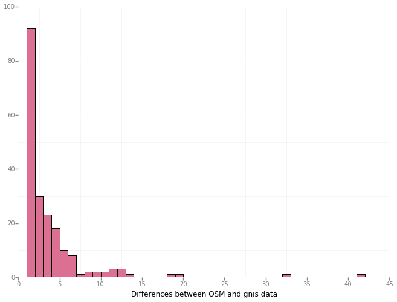

```python
#plot a histogram of the differences between the 'ele' tag and the USGS elevation data
differences = [np.abs(x) for x in elevation_differences.values()]
df = pd.DataFrame(differences, columns=['Differences between OSM and gnis data'])
p = ggplot(aes(x='Differences between OSM and gnis data'), data=df)
p + geom_histogram(binwidth=1, color="black",fill="palevioletred") + theme_bw()
```

**Cuisine**

- There are a number of cases where the same cuisine type is listed under different headings (e.g. "BBQ", "Barbecue" and "Bar-B-Q"). We will want to make a mapping dictionary so that we have uniform values in our database.
- There are some cuisine entries in which multiple cuisines are indicated by a single field. We should break those apart into an array of cuisine types.
- Some of the cuisine names are also national/ethnic names, and should be capitalized, while others are generic food types and should not be. We will use a list we found on ranker.com to check for which cuisine types should be capitalized.

see the code for `make_national_cuisine_list` and `get_cuisine` here.

**Address**

- There is a lack of standardization in how street names are represented. We want to import the street names in their full forms (e.g. "Lane" instead of "Ln."). We need to audit the data and create a mapping dictionary for making the needed conversions.
- We will also standardize compass point directions(e.g. N. = North)
- Postcodes are not uniform. Some have only a five digit code while others include an additional 4 digits. Some of the postcodes include a 'TX' prefix and at least one ('14150') clearly does not belong. We need a helper function that will filter out inappropriate zip codes, truncate the zip code to 5 digits and, where possible, also return the 'plus4' code under a seperate entry.

The code for auditing and cleaning the address data is here.

## Exporting to MongoDB

Now we would like to export the XML file to a MongoDB database. Then we can query that database to learn some interesting facts about Austin and to find points of interest.

First we write a function that will take in a node from the OSM datafile and return a dictionary. The key-value pairs of the dictionary are taken from the attributes and tags of the node. We will create a subdictionary called `created` for information about the creation of the node and an array called `pos` holding the geographical coordinates of the node. Later we can use this array to create a 2D index in MongoDB. As noted above, we will also create an array of cuisine types whenever we have a `cuisine` key.

See `node_to_dictionary` here.

Our next step is to create a JSON file using the `node_to_dictionary` function described above as follows:

```python
def make_json(filename):
    file_out = filename + ".json"
    with codecs.open(file_out, "w") as fo: #https://www.udacity.com/course/viewer#!/c-ud032-nd/l-768058569/e-865240067/m-863660253
        for item, elem in ET.iterparse(filename):
            if elem.tag == "node":
                new_dict = node_to_dictionary(elem)
                if new_dict:
                    fo.write(json.dumps(new_dict) + '\n')
```

```python
make_json(filename)
```

And then we use that file to create our MongoDB database.

```python
client = MongoClient()
db = client.austintexas
```

```python
with open('austin_texas.osm.json') as input:
    for line in input:
        data = json.loads(line)
        db.osm.insert(data)
```

## Querying the Database

Now we can query the database and answer some burning questions about Austin, TX.

**Question #1 - What is the relative size of each of the Christian denominations (measured by number of places of worship)?**

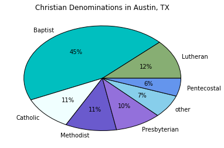

```python
result = db.osm.aggregate([{"$match" : {"religion" : "Christian", "denomination" : {"$exists" : 1}}},
                        {"$group" : {"_id" : "$denomination", "count" : {"$sum" : 1}}},
                         {"$sort" : {"count" : -1}}])

#we want to see a pie chart of the results
denominations = {x['_id'] : x['count'] for x in result['result']}

#limit the number of pie slices by compressing the 4 smallest denominations into an 'other' category
main_denominations = {x : y for x,y in denominations.items() if y >7}
main_denominations['other'] = sum(denominations.values()) - sum(main_denominations.values())

#http://matplotlib.org/examples/pie_and_polar_charts/pie_demo_features.html
types = [key for key in main_denominations.keys()]
counts = [float(value) for value in main_denominations.values()]
colors = ["sage", "c", "azure", "slateblue", "mediumpurple", "skyblue", "cornflowerblue"]

plt.pie(counts, labels=types, colors=colors, autopct='%1.f%%')
plt.title('Christian Denominations in Austin, TX')
plt.show()
```

**Question #2 - What are the highest points in the database?**

```python
result = db.osm.aggregate([{"$sort" : {"elevation" : -1}},
                           {"$limit" : 6},
                           {"$project" : {"_id" : 0,"name" : 1, 'elevation' : 1}}])

for x in result['result']:
    print x['name'].title(), x['elevation']
```

```
Soil Conservation Service Site 15 Dam 700
Jack Mountain 451
Roundtree Mountain 440
Mount Sharp Cemetery 437
Martin Cemetery 432
Shingle Hills 432
```

**Question #3 - What are the most common cuisine types in the database?**

```python
result = db.osm.aggregate([{"$unwind" : "$cuisine"},
                           {"$group" : {"_id" : "$cuisine", "count" : {"$sum" : 1} }},
                           {"$sort" : {"count" : -1}},
                           {"$limit" : 10}
                          ])
for x in result['result']:
    print x['_id'], x['count']
```

```
Mexican 71
burger 49
pizza 38
sandwich 35
Chinese 21
American 20
coffee shop 18
Indian 15
Italian 13
Thai 13
```

**Question 4 - What are the closest Mexican restaurant to my current location?**

```python
#first we need to create a geospatial index on the 'pos' field of our documents.
db.osm.ensure_index([('pos', pymongo.GEO2D)])
```

```
u'pos_2d'
```

```python
my_loc = [-97.753333, 30.349167]
for doc in db.osm.find({"cuisine" : "Mexican","pos" : {"$near" : my_loc}}, { "name" : 1, "_id" : 0, 'address.housenumber' : 1}).limit(5):
    print doc['name'].title()
```

```
Arandas
Chipotle Mexican Grill
Torchy'S Tacos
Panaderia
El Nuevo Mexico
```

**Question #5 - What are the closest natural sites?**

```python
for doc in db.osm.find({"natural" : {"$exists" : 1}, "name" : {"$exists" : 1}, "pos" : {"$near" : my_loc}},
                       { "name" : 1, "_id" : 0}).limit(5):
    print doc['name'].title()
```

```
Cat Mountain
Mount Lucas
Mount Barker
Mount Bonnell
Mount Larson
```

**Question #6 - How do I find the closest amenities to a given address?**

```python
#this function finds the closest amenities to the supplied address, if the address is not in the db, return None
def find_closest(housenumber, street, amenity):
    current_loc = db.osm.find_one({'address.housenumber' : housenumber, 'address.street' : street}, {"pos" : 1})
    if not current_loc:
        return None
    return db.osm.find({'amenity' : amenity, 'pos' : {"$near" : current_loc['pos']}}, {"_id" : 0, "name" : 1, "address.housenumber" : 1,
                                                                                "address.street" : 1}).limit(5)
```

```python
#find the closest bars
locations = find_closest('2911', 'San Jacinto Boulevard', 'bar')

if locations:
    for loc in locations:
        print loc['name'].title()
        if 'address' in loc:
            print loc['address']['housenumber'] + " " + loc['address']['street']
        print "-------"
else:
    print "Address not found!"
```

```
Cactus Cafe
2247 Guadalupe Street
-------
Nast'Y
-------
Dive
1703 Guadalupe Street
-------
Haymaker
2310 Manor Road
-------
Mohawk
912 Red River Street
-------
```

## Conclusion

First an overview of the file(s) used: - Size of original OSM file: 174.6 MB - Size of intermediary JSON file: 140 MB - Size of MongoDB database: 67.1 MB - Number of unique contributors: 761 - Number of nodes: 761182

The analysis above represents only some of the steps that would be taken to clean and improve the data that we received from OSM. It is clear from the start that the data here are only a partial representation of the actual points in Austin. For example, there is a Mexican restaurant across the street from me that is not in the database. In addition to being incomplete, we can not even be certain that the data are representative. It may be, for example, that Baptist churches are, for some reason, more likely to have been added to the database than the churches of other denominations. Furthermore, we only examined and cleaned a few of the tags that exist in the database, no doubt each of the other tags would require similar efforts to clean and improve.

One of the best ways that the data could be improved would be the inclusion of relevant data from the City of Austin Data Portal. This site has numerous datasets that could be used to correct, refine and expand the data we have collected here. Datasets include locations of dangerous dogs, golf courses, police and fire station locations and many more. An especially useful improvement to the database would be to add entries for restaurant inspection scores that would be even more useful than proximity data in deciding where to eat.

## Resources

The primary source of technical information used to complete this project was provided by Udacity's [DataWrangling with MongoDB](https://www.udacity.com/course/viewer#!/c-ud032-nd/l-491558559/m-816599080) course.

Other resources consulted include:

- the [the MongoDB manual](http://docs.mongodb.org/manual/tutorial/getting-started/).
- Python's [JSON documentation](https://docs.python.org/2/library/json.html).
- Python's [ElementTree documentation](https://docs.python.org/2/library/xml.etree.elementtree.html).

Cases where specific code segments were borrowed from other sources are commented within the code in the appendix.

The following files were used to build the database:

- `austin_texas.osm` from Open Street Map's Austin, TX [metro extract](https://mapzen.com/metro-extracts/).
- `TX_Features_20141202.txt` provided by the US Geological Survey.
- `cuisine_list.txt` from ranker.com's [list of most popular national cuisines](http://www.ranker.com/crowdranked-list/favorite-types-of-cuisine).

Return to top

## Code

**Import necessary modules**

```python
#import the modules I will need
import xml.etree.ElementTree as ET
import pprint
import csv
import pandas as pd
from ggplot import *
from scipy import stats
import numpy as np
import collections
import re
from pymongo import MongoClient
import datetime
import time
from pymongo import MongoClient
import pymongo
import matplotlib.pyplot as plt
import json
import codecs

#we have a graph to show later
%matplotlib inline
```

**Designate input file**

```python
filename = 'austin_texas.osm'
```

**Count the tags in the database**

```python
#count the tags in our database
def count_tags(filename):
    tags = {}
    for item, elem in ET.iterparse(filename):
        if elem.tag not in tags:
            tags[elem.tag] = 1
        else:
            tags[elem.tag] += 1
    return tags
```

Return to Auditing & Cleaning

**Count the keys in the nodes**

```python
def count_keys(filename):
    tag_keys = collections.Counter()
    for item, elem in ET.iterparse(filename):
        if elem.tag == 'node':
            for x in elem:
                tag_keys[x.attrib['k']] += 1
    return tag_keys
```

Return to Auditing & Cleaning

**Clean the religion and denomination names**

```python
#clean the religion and denomination names
def clean_religion(entry):
    new_entry = entry.lower()
    if new_entry == "latter_day_saints":
        return "Mormon"
    if new_entry == "roman_catholic":
        return "Catholic"
    if 'jehovahs' in new_entry:
        return "Jehovah's Witness"
    return entry.replace('_',' ').title()
```

Return to religion/denomination

###### Import GNIS data from the USGS and compare with the OSM data

```python
#We want a list of gnis:feature_ids that are in our OSM data, we will then extract those features from the gnis data
gnis_features = []
for item, elem in ET.iterparse(filename):
    if elem.tag == 'node':
        for x in elem:
            if x.attrib['k'] == "gnis:feature_id":
                if ";" in str(x.attrib['v']):
                    for q in x.attrib['v'].split(';'):
                        gnis_features.append(q)
                else:
                    gnis_features.append(x.attrib['v'])

#now we import the data from the USGS which includes data on the elevation. We will only import the ones that exist in the OSM
#database. See below for an example entry from these data.
gnis_data = []
with open('TX_Features_20141202.txt', 'rb') as csvfile:
    reader = csv.DictReader(csvfile, delimiter='|')
    for line in reader:
        if line['\xef\xbb\xbfFEATURE_ID'] in gnis_features: #the data we have include all of TX, but we just want the points in OSM
            gnis_data.append(line)

#finally, we compare the elevations from the two difference datasets and create a dictionary of features and the elevations
#differences
elevation_differences = {}
for item, elem in ET.iterparse('austin_texas.osm'):
    if elem.tag == 'node':
        OSM_ele = None
        for tag in elem: #first get the OSM elevation
            if tag.attrib['k'] == 'ele':
                OSM_ele = tag.attrib['v']
        if not OSM_ele:
            continue
        for tag in elem: #now get the gnis elevation
           if tag.attrib['k'] == 'gnis:feature_id':
                for item in gnis_data:
                    if item['\xef\xbb\xbfFEATURE_ID'] == tag.attrib['v']:
                        if item['ELEV_IN_M'] != OSM_ele:
                            for name in elem:
                                if name.attrib['k'] == 'name':
                                    elevation_differences[name.attrib['v']] = int(OSM_ele) - int(item['ELEV_IN_M'])

#this function creates a dictionary from the USGS data with entries like this {feature_id : elevation}
def get_gnis_elevations(gnis_textfile):
    gnis_elevations = {}
    with open(gnis_textfile, 'rb') as csvfile:
            reader = csv.DictReader(csvfile, delimiter='|')
            for line in reader:
                if line['ELEV_IN_M'] != '':
                    gnis_elevations[line['\xef\xbb\xbfFEATURE_ID']] = int(line['ELEV_IN_M'])
                else:
                    gnis_elevations[line['\xef\xbb\xbfFEATURE_ID']] = None
    return gnis_elevations

gnis_elevations = get_gnis_elevations('TX_Features_20141202.txt')
```

Return to elevation

###### Audit and clean the cuisine types

```python
#first we will generate the list of cuisine types that should be capitalized from the ranker.com list we found.
def make_national_cuisine_list(filename):
    national_cuisine_list = []
    with open(filename, 'rb') as cuisines:
        for line in cuisines:
            national_cuisine_list.append(line.split()[1].strip().lower())
    #we need to add a couple to this list
    national_cuisine_list.extend(['salvadoran', 'columbian', 'jamaican', 'asian', 'middle eastern'])

    return national_cuisine_list

national_cuisine_list = make_national_cuisine_list('cuisine_list.txt')

#and now the function for cleaning cuisine types
def get_cuisine(cuisine_type, cuisine_list):
    cuisine_dictionary = {'barbecue' : 'bbq', 'Texas Style BBQ' : 'bbq', 'Bar-B-Q' : 'bbq', 'Hamburgers and fires' : 'burger',
                      'Sandwich shop' : 'sandwich', 'mediteranian' : 'Mediterranean', 'el_salvadorian' : 'salvadoran'}
    if cuisine_type in cuisine_dictionary:
        cuisine_type = cuisine_dictionary[cuisine_type]
    cleaned = cuisine_type.replace('_', ' ').strip()
    cleaned = cleaned.lower().replace('fusion', '')
    #split any that require splitting
    if ',' in cleaned:
        cleaned = [x.strip() for x in cleaned.split(',')]
        #after the split we need to check the new entries against our dictionary
        cleaned = [cuisine_dictionary[type] if type in cuisine_dictionary else type for type in cleaned]
    elif '/' in cleaned:
        cleaned = cleaned.split('/')
        #after the split we need to check the new entries against our dictionary
        cleaned = [cuisine_dictionary[type] if type in cuisine_dictionary else type for type in cleaned]
    elif cleaned == 'mexican korean': #this one had to be hard coded since the only seperator was '_'
        cleaned = ['mexican', 'korean']

    else:
        cleaned = [cleaned]
    return [x.capitalize().strip() if x.strip() in national_cuisine_list else x.strip() for x in cleaned]
```

Return to cuisine

###### Audit and clean the address data

```python
#the regex for extracting the last word in the input string.
street_type_re = re.compile(r'\b\S+\.?$', re.IGNORECASE)

#these are the acceptable names for street types, if the last word is not one of these we want to know
expected = ["Street", "Avenue", "Boulevard", "Drive", "Court", "Place", "Square", "Lane", "Road",
            "Trail", "Parkway", "Commons", "Expressway", "Cove", "Crossing", "Way", "Pass", "Path", "Loop", "Highway", "Quarry"]

#we build the mapping below to make sure that all of the abbreviations are matched to the full equivalent
mapping = {"St" : "Street", "St.": "Street", "Dr." : "Drive", "Ave" : "Avenue", "Rd" : "Road", "street" : "Street", "Blvd" : "Boulevard",
               "Blvd." : "Boulevard", "Dr" : "Drive", "Pkwy" : "Parkway", "Ln" : "Lane", "Avene" : "Avenue", "Cv" : "Cove", "CR" : "Circle",
               "Cir" : "Circle", "Ct" : "Court", "RD" : "Road", "Expwy" : "Expressway", "lane" : "Lane", "N." : "North", "N" : "North", "W." : "West",
               "W" : "West" , "E" : "East", "E." : "East", "S." : "South", "S" : "South", "U.S." : "US", "Hwy" : "Highway",
               "dr." : "Drive", "rd" : "road", "ave" : "Avenue", "ln" : "Lane", "st" : "Street", "st." : "Street", "blvd." : "Boulevard",
               "rd" : "Road", "blvd" : "Boulevard", "dr" : "Drive", "sb" : "Southbound", "ih" : "Interstate", "ih35" : "Interstate 35",
               "i" : "Interstate", "fm" : "Farm to Market", "rr" : "Rural Route"}
#we want the keys of mapping to be lower case, but we don't want to retype the whole thing, so:

mapping = {k.lower(): v for k,v in mapping.items()}
#see street types
def audit_street_types(filename):
    for item,elem in ET.iterparse(filename, events = ('start', )):
        if elem.tag == 'node':
            for tag in elem.findall('tag'):
                if tag.attrib['k'] == 'addr:street':
                    m = street_type_re.search(tag.attrib['v'])
                    if m:
                        street_type = m.group()
                        if street_type not in expected and street_type not in mapping:
                            print tag.attrib['v']

#this function shows the street names that exist in the data

def audit_street_types(filename):
    for item,elem in ET.iterparse(filename, events = ('start', )):
        if elem.tag == 'node':
            for tag in elem.findall('tag'):
                if tag.attrib['k'] == 'addr:street':
                    m = street_type_re.search(tag.attrib['v'])
                    if m:
                        street_type = m.group()
                        if street_type not in expected and street_type not in mapping:
                            print tag.attrib['v']

#this function, when passed a street name and a mapping, cleans it and returns the new name for insertion into the database

def clean_streetname(name, mapping):
    new_name = ""
    name = name.replace("-", " ")
    for i in name.split():
        if i.lower() in mapping:
            new_name += mapping[i.lower()]
        else:
            new_name += i.capitalize()
        new_name += " "
    return new_name.strip()

#this function takes in a postcode from the OSM file and return the cleaned postcode and the seperate 4plus code where possible
#http://stackoverflow.com/questions/2499966/python-a-smarter-way-of-string-to-integer-conversion/2500023#2500023
def clean_zipcode(zipcode):
    new_zip_4 = None
    new_zip = ''.join([x for x in zipcode if x.isdigit()])
    if len(new_zip) > 5:
        new_zip_4 = new_zip[5:]
        new_zip = new_zip[0:5]
    if 73000 > int(new_zip) < 79000:
        return None

    return new_zip, new_zip_4
```

Return to address

**Create dictionaries from nodes**

```python
#fields that should be in the created subdictionary
CREATED = [ "version", "changeset", "timestamp", "user", "uid", "created_by", "version"]
#the fields we are interested in
KEYS_TO_IMPORT = ["amenity", "natural", "emergency", "public_transport", "leisure", "shelter", "waterway", "aeroway",
                  "name", "historic", "created_by", "name"]

def node_to_dictionary(node):
    #initialize necessary dictionaries and lists
    new_document = {}
    created_dict = {}
    address = {}
    cuisine = []
    #get the attributes of the node - import them into the appropriate dictionary
    for value in node.attrib:
        if value in CREATED:
            created_dict[value] = node.attrib[value]
        else:
            new_document[value] = node.attrib[value]
    #convert the timestamp from OSM to a Python time.struct
    """if 'timestamp' in created_dict:
        newtime = datetime.datetime.strptime(created_dict['timestamp'], "%Y-%m-%dT%H:%M:%SZ")
        created_dict['timestamp'] = newtime"""
    #combine the lat and lon values into a single list entry 'pos' and convert the values to floats
    if 'lat' in new_document and 'lon' in new_document:
        #[lon, lat] so we can use it as a geospatial index later - http://docs.mongodb.org/manual/core/2dsphere/
        new_document['pos'] = [float(new_document['lon']), float(new_document['lat'])]
        del (new_document['lat'], new_document['lon'])
    #now import the tags calling helper functions as needed to process the incoming data
    for tag in node.findall('tag'):
        new_key = tag.attrib['k'].lower().strip()
        new_value = tag.attrib['v'].lower().strip()
        if new_key in CREATED:
            created_dict[new_key] = new_value
        if new_key == 'religion' or new_key == 'denomination':
            new_document[new_key] = clean_religion(new_value)
        if new_key == "gnis:feature_id":
            #get the ele from this node
            for x in node.findall('tag'):
                if x.attrib['k'] == "ele":
                    OSM_elevation = int(x.attrib['v'])
            #get the elevation from the USGS GNIS
            if new_value not in gnis_elevations:
                continue
            GNIS_elevation = gnis_elevations[new_value]
            if OSM_elevation == GNIS_elevation:
                new_document['elevation'] = GNIS_elevation
            else:
                new_document['elevation'] = GNIS_elevation
                new_document['old_elevation'] = OSM_elevation
            new_document['ele_gnis_verified'] = True
            continue
        if new_key == 'ele':
            new_document['elevation'] = int(float(new_value))
            new_document['ele_gnis_verified'] = False
        if new_key == "cuisine":
            cuisine = get_cuisine(new_value, national_cuisine_list)
        #clean our postcodes and street names
        if new_key[0:5] == "addr:":
            if new_key[5:] == "postcode":
                post_code = clean_zipcode(new_value)
                if post_code:
                    address['postcode'] = post_code[0]
                    if post_code[1] != None:
                        address['zipplus4'] = post_code[1]
            elif new_key[5:] == "street":
                address['street'] = clean_streetname(new_value, mapping)
            else:
                address[new_key[5:]] = new_value
        #if it's not on our list, ignore it
        if new_key not in KEYS_TO_IMPORT:
            continue
        #import whatever's left
        new_document[new_key] = new_value
    if cuisine != []:
      new_document['cuisine'] = cuisine
    if address != {}:
        new_document['address'] = address
    new_document['created'] = created_dict
    return new_document
```

Return to file export